# Kayla Park

I build tools that help young people feel heard.

A psychology-focused student pairing research with the everyday support teens actually reach for: founder of an anonymous peer-support app, co-author of a peer-reviewed study of New York City’s supervised consumption sites, author of a seven-book children’s series on emotions, and a cellist.

Read the research [Explore Mo Soop](https://mo-soop.glide.page) [Explore Mo Ri](https://mo-ri.glide.page) [The books](https://www.amazon.com/dp/B0HMK46R5G) [BCYA](https://bcyouthassembly.org) Get in touch

4.7

Weighted GPA · AP Psychology

Apr 2026

Mo Soop peer-support app, live

$15K+

Clothing distributed to children

Carnegie Hall

Selected cello performer

## About

Psychology-focused student interested in mental health, human behavior, and access to care. I founded a youth-led peer-support initiative, use R to study how harm-reduction services shape behavior in New York City neighborhoods, and connect writing and music to service, a consistent through-line of using evidence and empathy to support young people.

**Leonia High School**, Leonia, NJ · Expected June 2027  
GPA 4.7 weighted / 3.84 unweighted · 10 AP courses (5 completed, 5 senior year) incl. AP Psychology · National, Rho Kappa & Science Honor Societies

**AP Scholar with Distinction** (College Board, 2026).

**Certifications**, Psychological First Aid (PFA) and Skills for Psychological Recovery (SPR), completed through the NCTSN / National Center for PTSD (2026).

## Research

I study how a person’s surroundings shape behavior. In this project I asked whether New York City’s two supervised consumption sites, where people can use drugs under medical supervision, changed the drug use that neighbors see on the street. I measured that behavior with two public records: EMS calls for drug-related emergencies and 311 complaints about discarded syringes.

Independent Research: Supervised Consumption Sites and Neighborhood Behavior2024 to Present

- Co-authored with Eunice Cho (first author) and mentored by Johns Hopkins biostatistician Hyunsoo (Brian) Song.
- Collected and cleaned EMS dispatch records (2018 to 2024), 311 syringe complaints (2019 to 2024), and U.S. Census data for 46 Manhattan ZIP codes, then wrote the full analysis in R.
- Wrote the methods, results, and discussion sections of “Beyond the Facility Walls: A Geospatial Analysis on Supervised Consumption Sites and Its Neighborhood Effects,” published in the National High School Journal of Science after peer review (NHSJS Reports, November 6, 2026). [Read the paper](https://nhsjs.com/2026/beyond-the-facility-walls-a-geospatial-analysis-on-supervised-consumption-sites-and-its-neighborhood-effects/).

Four questions, four methods

Where

Where does the behavior cluster?

Global Moran’s I on rates per 10,000 residents, tested with 999 permutations, and Local Moran’s I with a Benjamini-Hochberg correction for multiple comparisons.

Change

Did behavior change after the sites opened?

A Poisson difference-in-differences model on a ZIP code by month panel with ZIP code and month fixed effects, an event study to test parallel trends, and a negative binomial refit for overdispersion.

Confidence

How sure can we be?

Randomization inference with 1,000 placebo pairs of ZIP codes, CR2 small-sample tests, fake opening dates, four comparison-group definitions, and a HonestDiD sensitivity analysis.

Context

Who lives where help is placed?

Logistic regression of site proximity on poverty, private insurance, race, and median age, checked with variance inflation factors, McFadden’s pseudo-R², and the Hosmer-Lemeshow test.

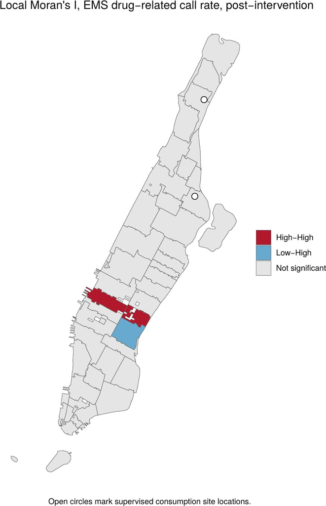

Local Moran’s I for EMS drug-related calls per 10,000 residents after the sites opened. Two Midtown ZIP codes (10017 and 10036) form the only significant high-rate cluster. Neither site, marked with an open circle, falls inside it.

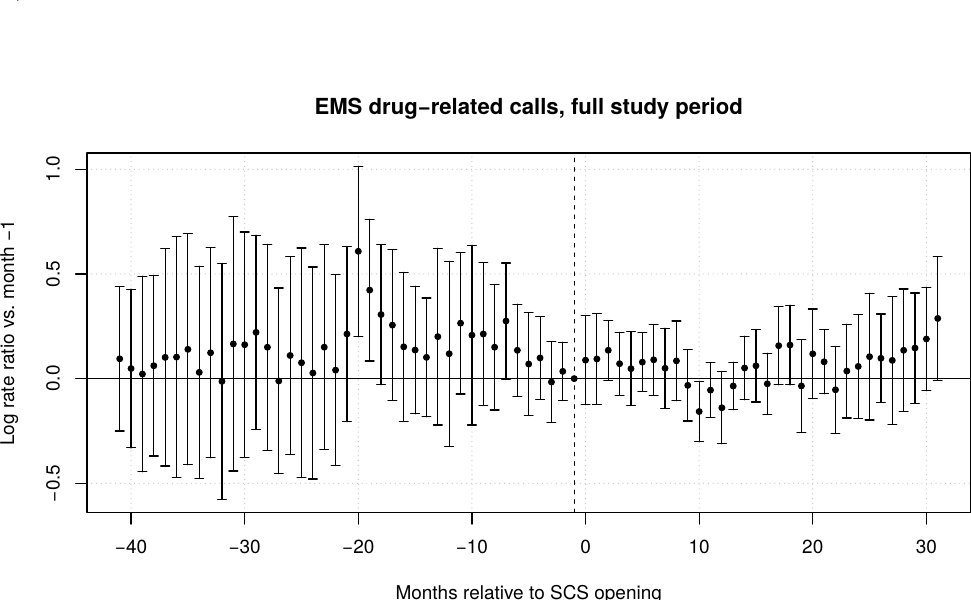

What I found

- Per-resident rates clustered in Midtown (EMS calls: 10017 and 10036; syringe complaints: 10016, 10017, 10018, and 10036), not in East Harlem or Washington Heights, where the sites are located. Because few people live in these commercial ZIP codes, their rates partly reflect commuters and visitors.
- After the sites opened, EMS calls near them showed no clear change. The estimate even switched direction between models.
- Syringe complaints near the sites fell by about a third in every version of the model, but the drop did not reach statistical significance (randomization p = .052).
- In 10033, the one ZIP code within half a mile of a site, EMS calls rose 19.6% and syringe complaints fell 37.8%. Neither contrast held up under randomization tests. The paper raises one possibility: overdoses near a site are more likely to be witnessed and reported by staff.
- Tested one at a time, the ZIP codes near the sites had more poverty, less private insurance, and larger non-white populations.

Why this matters to me as a psychology student

What drew me to this project was that it put behavior on a map. A psychology study usually looks at a person: their stress, their choices, what they say on a survey. My data showed the same behavior, public drug use, as a pattern across a city, and once it was on a map I could ask a different question: not only who does this but where, and what is around them. The answer was that the events clustered in commercial Midtown, far from the sites, and that the sites themselves sit in neighborhoods with more poverty and less insurance. That is the environment shaping the decision, long before any one person makes it. It is the same idea behind Mo Soop, the anonymous peer-support app I co-built: a teen decides whether to speak based on the space you give them. In college I want to keep studying behavior this way, as something that happens between a person and the place they are in.

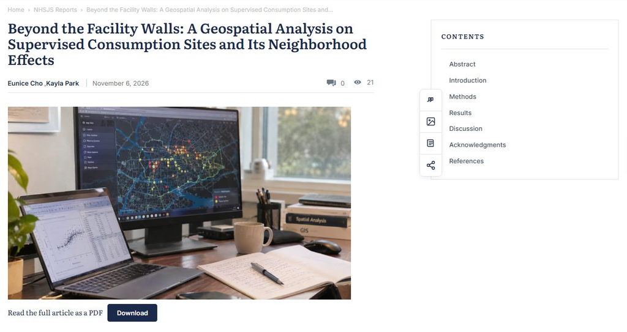

Published in *NHSJS Reports*, November 6, 2026. Click to read the paper.

From the code

Difference-in-differences with ZIP code and month fixed effects

```
fit_did <- function(p)
  fepois(y ~ treated:post + treated:phasein | ZIPCODE + month_fe,
         data = p, offset = ~log(Population), cluster = ~ZIPCODE)
```

Event study: one coefficient for every month relative to the opening

```
fit_es <- function(p)
  fepois(y ~ i(rel_month, treated, ref = -1) | ZIPCODE + month_fe,
         data = p, offset = ~log(Population), cluster = ~ZIPCODE)
```

Randomization inference: 1,000 placebo pairs of ZIP codes

```
draws <- map_dbl(seq_len(B), function(i) {
  fh <- sample(cand, 2)
  fn <- unique(unlist(lapply(fh, near_of)))
  dd <- p %>% mutate(tp = as.integer(ZIPCODE %in% fn) * post)
  coef(fepois(y ~ tp | ZIPCODE + month_fe, data = dd,
              offset = ~log(Population)))[["tp"]]
})
ri_p <- mean(abs(draws) >= abs(obs))
```

View the full analysis code Download analysis.Rmd

**Tools:** R (tidyverse, sf, spdep, fixest, clubSandwich, HonestDiD) · NYC Open Data (EMS Incident Dispatch, 311 Service Requests) · U.S. Census Bureau

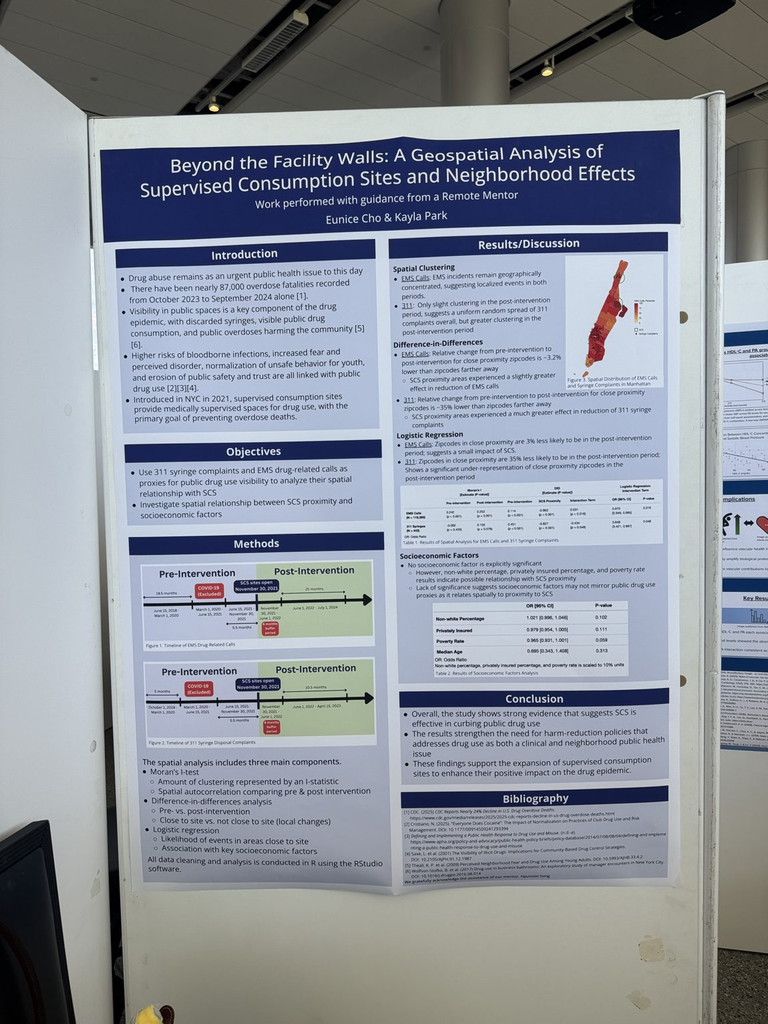

Research poster, “Beyond the Facility Walls: A Geospatial Analysis of Supervised Consumption Sites and Neighborhood Effects,” co-presented with Eunice Cho.

## Mental Health & Youth Advocacy

VOY Mental Health Initiative, Founder & President2024 to Present

- Founded a student-led mental health initiative after identifying gaps in peer support, growing it into an ongoing program of wellness and stress-management resources.
- Designed and launched **Mo Soop** (April 2026), an anonymous peer-support app where students share stress without judgment and find encouragement, modeled on the Korean idea of a safe “bamboo forest.”
- Led a Finals Relief Project: student volunteers 3D-printed and donated 150 stress-relief clickers to Fort Lee High School during finals season.
- Conceived and launched **Mo Ri** (October 2026), an app that helps high school students with ADHD handle both school and social situations. While developing Mo Ri, read research on ERIC and reports from the CDC and CHADD, and completed CHADD’s ADHD 101 course.

[Open Mo Soop](https://mo-soop.glide.page) [Open Mo Ri](https://mo-ri.glide.page)

“Benched”: A YGLE Documentary on College Athletes, Interview & Human Story Lead2025 to 2026

- A Young Global Leaders of the East documentary on college athletes whose playing careers end, and how they navigate identity, mental health, and life after sports. [Watch BENCHED on YouTube](https://youtu.be/e59UKk2K4_g).
- Led the interviews and the human story: reached out to the athletes, shaped the interview questions and the film’s psychological framing, and connected subjects with peer mental health resources.

[video not shown]

BENCHED, a YGLE documentary on college athletes whose playing careers end. Kayla was the Interview and Human Story Lead.

Mia’s Feelings Lab: Psychology Chapter-Book Series (Ages 7 to 13), Author2026 to Present

- Wrote all seven books in the series, illustrated by Sharon Kwon, and self-published them on Amazon in paperback and Kindle in 2026. Each book answers an emotional question kids ask: why they get angry, feel shy around new people, feel left out, feel scared of the dark, feel sad, get jealous, or worry so much.
- Grounds each story in real psychology, from the amygdala’s alarm system to social pain and cognitive distortions, and closes every book with a hands-on “Feelings Lab” activity that helps children apply the idea to their own lives.
- An exercise in translating clinical concepts into warm, age-appropriate storytelling. Through the Bergen County Youth Assembly, copies were donated in October 2026 to six public libraries: Old Tappan, Harrington Park, Ridgefield Park, Leonia, Palisades Park, and Englewood.

[Why Do I Get So Angry?View on Amazon](https://www.amazon.com/dp/B0HMK3VC4M)[Why Am I Shy Around New People?View on Amazon](https://www.amazon.com/dp/B0HMKHFWYZ)[Why Do I Feel Left Out?View on Amazon](https://www.amazon.com/dp/B0HMN4LVDF)[Why Am I Scared of the Dark?View on Amazon](https://www.amazon.com/dp/B0HMN93HPH)[Why Do I Feel Sad Sometimes?View on Amazon](https://www.amazon.com/dp/B0HMK46R5G)[Why Do I Get Jealous?View on Amazon](https://www.amazon.com/dp/B0HMK46R5G)[Why Do I Worry So Much?View on Amazon](https://www.amazon.com/dp/B0HMK46R5G)[The full seriesAll 7 books on Amazon](https://www.amazon.com/dp/B0HMK46R5G)

New Sky Auto Body, Wellness Program Intern2026

- Invited by the shop’s owner to help ease strain among the younger technicians, designing and facilitating workplace sessions on communication, stress management, and coping with personal hardship.
- The sessions surfaced long-standing misunderstandings among the staff and helped resolve them; the owner credited the program with noticeably improved workplace relationships.
- A rare chance to apply psychology outside the classroom, with adults, in a real workplace.

## Leadership & Community Service

Bergen County Youth Assembly (BCYA), Founder & Chair2025 to Present

- Founded a nonpartisan, student-led youth organization serving Bergen County; active since November 2025 and formally established on July 11, 2026.
- Serves as Director of Youth Mental Wellness, leading the group’s mental-wellness work alongside free student resources and peer tutoring delivered through schools and community partners.
- Wrote and edited **The Reset**, a stress and resilience toolkit for high school students (a guide, a wallet card, and a stress-relief clicker) with a companion one-page guide for parents and trusted adults. A Bergen Community College psychology professor reviewed it before release. Presented it with a costed youth wellness proposal to Leonia’s mayor in September 2026, who referred it to Stigma-Free Leonia; now working through that committee to bring a Leonia edition of the kit to students.
- Led distribution of 300 printed copies of **Before You Vote**, a student-written BCYA guide to elections and first-time voting, to Bergen County public libraries and a high school.

[figure not shown]

The ResetStudent toolkit

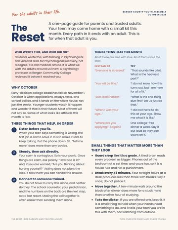

The Reset for ParentsOne-page guide

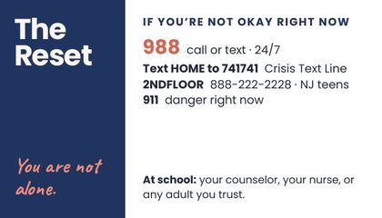

The Reset Wallet CardCrisis numbers and a 60-second reset

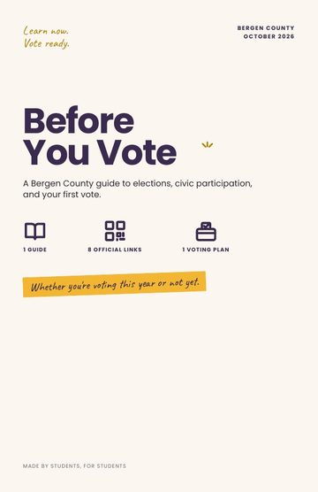

Before You Vote300 copies to libraries

[Visit BCYA](https://bcyouthassembly.org/)

Young Global Leaders of the East (YGLE), President2023 to Present

- Lead a student-run organization, directing volunteer, cultural, and youth-empowerment programming through the year.
- Led the rollout of **THE WAIT**, 300 Korean-English patient communication cards reviewed by a registered nurse and a dentist, plus 20 large-print posters on free and low-cost care; the cards were donated to Korean community organizations in New Jersey and New York, with a second printing of 500 planned.
- Launched the organization’s first Global Leadership Forum, convening peers to examine youth social issues. *Young Leadership Award (2025).*

[figure not shown]

THE WAIT CardKorean-English communication card for hospital and dental visits; 300 printed

[figure not shown]

THE WAIT FlyersLarge-print guide to free and low-cost care; 20 posters

Clothing Donations to Help Kids in the World (CDHW), President2023 to Present

- Direct a student nonprofit that has distributed $15,000+ in clothing to hospitalized children and families in need.
- Expanding the program’s reach to children in foster care nationwide. *Outstanding Service Milestone, 200+ hours (2026).*

Liberty in North Korea (LiNK), North Jersey Rescue Team, Student Leader2023 to Present

- Lead a student chapter advocating for North Korean refugees, authoring educational materials that build peer awareness of human rights.
- Organize fundraising campaigns supporting refugee rescue and resettlement. *Chapter Recognition Award (2025).*

Walk Alongside Tutoring Program, Lead Mentor2022 to Present

- Mentor underserved students weekly, pairing academic support with the confidence that keeps them engaged.
- Recruit and coordinate volunteer tutors and build the curriculum they teach from. *Tutor of the Year (2025).*

[figure not shown]

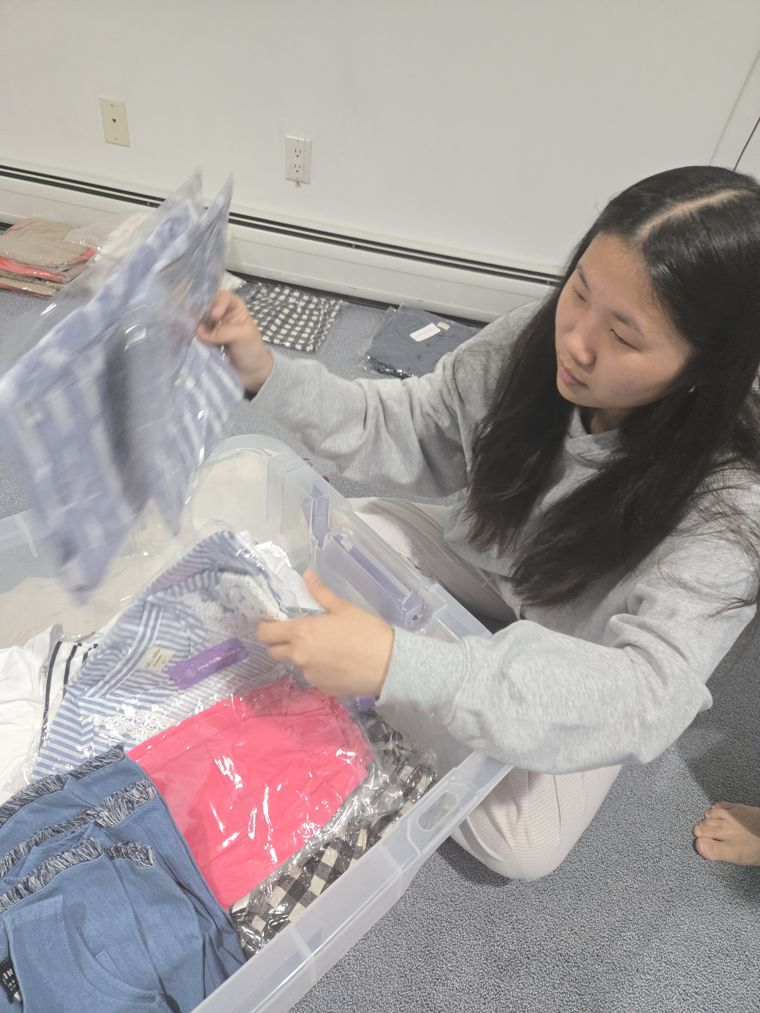

[figure not shown]

In the community: delivering clothing to Hackensack Meridian Children’s Hospital, preparing CDHW donations, and mentoring with Walk Alongside.

## Honors & Awards

[figure not shown]

John Locke Institute Global Essay Prize in Psychology: Very High Commendation (2026).

[figure not shown]

Scholastic Art & Writing Awards: Gold Key (2025).

Writing & Scholarship

John Locke Institute Global Essay Prize in Psychology: Very High Commendation (2026)

Awarded Very High Commendation in the Psychology category of the Oxford-based John Locke Institute’s 2026 Global Essay Prize, the highest of the competition’s commendation levels. This year the prize drew 100,227 entrants from 183 countries; the award was presented at the ceremony at Grosvenor House in London on October 3, 2026.

NJ Hall of Fame Essay Contest, First Place, High School (2025)

Selected statewide by the NJ Hall of Fame and NJEA for an essay on Senator Andy Kim, how his election breaks barriers and redefines representation in New Jersey. [Read the announcement](https://njhalloffame.org/2025/06/new-jersey-hall-of-fame-announces-2025-essay-contest-and-arete-scholarship-recipients/)

Scholastic Art & Writing, Gold Key (2025)

“The Changing Face of Mental Health Narratives in Literature,” on how storytelling shapes public perception of mental illness.

Peace Islands Art & Essay Contest: First Place, High School Essay (2025)

“You are Enough: The First Step to Peace.” Honored by then-Congresswoman (now Governor) Mikie Sherrill.[See the official results](https://artandessay.org/2025-archive/)[Read the essay](https://artandessay.org/wp-content/uploads/2026/02/1st-ESHS8519.docx.pdf)

College Board National Recognition (2025)

First-Generation Recognition Award for academic achievement.

[figure not shown]

[figure not shown]

Accepting first place at the Peace Islands Institute 15th Annual Art & Essay Contest (high school), recognized with a U.S. House of Representatives citation from Rep. (now Gov.) Mikie Sherrill.

Music

WorldStrides Maestro Award (2026)

Outstanding solo cello performance; carries an invitation to perform at Carnegie Hall.

NY Youth Symphony Chamber Program (2025 to 2026)

Selected among the program’s top 10 musicians to perform at Carnegie Hall.

VITAS International Music Competition, First Place (2026)

National recognition for classical performance.

Performed at Laeiszhalle Recital Hall, Hamburg, Germany.

## Music & Arts

[figure not shown]

Performing at a hospital concert through the SMYH Foundation, offering comfort through music.

Cello runs through everything I do, from All-State Orchestra and chamber music at Carnegie Hall to volunteer concerts for patients. The same attention I bring to a phrase of music, I bring to listening to the people around me.

Tri-M Music Honor Society, PresidentLead the school’s music honor society, service performances and peer mentorship.2026 to Present

SMYH Foundation, Music Therapy VolunteerHospital concerts offering comfort and connection to elderly and ill patients.2023 to Present

NJMEA All-State OrchestraSeat by competitive audition in New Jersey’s top student orchestra.2022 to 2025

NJSMA Region I OrchestraAssistant Principal cellist; tied for the top audition score (2026).2021 to 2026

ARCO Educational Program, Teaching AssistantMentor younger cellists in technique and musicianship.2023 to Present

Performances

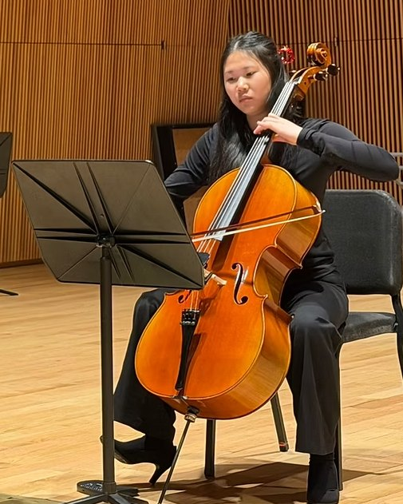

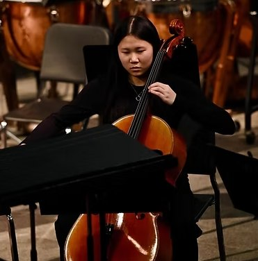

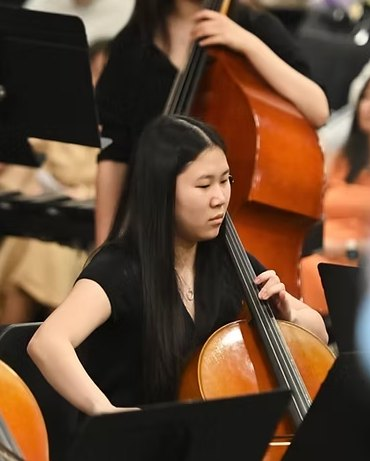

[▶ **Schumann, Cello Concerto in A minor, Op. 129**I. Nicht zu schnellWatch on YouTube](https://www.youtube.com/watch?v=cwi2x_4xfSk) [▶ **Elgar, Cello Concerto in E minor**IV. AllegroWatch on YouTube](https://www.youtube.com/watch?v=RdMwxsNrKTM) [▶ **Kahn, Piano Quartet in A minor**Op. 30, Movement IWatch on YouTube](https://www.youtube.com/watch?v=8aeZ2tViDPk) [▶ **Ravel, Alborada del gracioso**Watch on YouTube](https://www.youtube.com/watch?v=5NnSQWKyP0w)